# Wine Quality EDA

Amgad Khalil

2024-04-21

# **Data Background**

This datasets is related to `White` variants of the Portuguese **“Vinho Verde”** wine.The dataset describes the amount of various chemicals present in wine and their effect on it’s quality.The classes are ordered and not balanced (e.g. there are much more normal wines than excellent or poor ones). Each wine sample is accompanied by a quality rating assigned by human tasters, reflecting its overall perceived quality.

This data frame contains the following columns:

Input variables (based on physicochemical tests):  
1 - fixed acidity  
2 - volatile acidity  
3 - citric acid  
4 - residual sugar  
5 - chlorides  
6 - free sulfur dioxide  
7 - total sulfur dioxide  
8 - density  
9 - pH  
10 - sulphates  
11 - alcohol  
Output variable (based on sensory data):  
12 - quality (score between 0 and 10)

# **Problem Understanding**

1. **Regression Problem**: Predict the `numerical quality` score of a wine based on its physicochemical properties. leading to `predicting` future data without depending on experts for the `quality`.

# **Data Understanding(Statistics)**

### **Loading and viewing dataset**:-

```r
white_wine <- read.csv("Data/wine+quality/winequality-white.csv", header = TRUE, sep = ";")
head(white_wine)
```

```
##   fixed.acidity volatile.acidity citric.acid residual.sugar chlorides
## 1           7.0             0.27        0.36           20.7     0.045
## 2           6.3             0.30        0.34            1.6     0.049
## 3           8.1             0.28        0.40            6.9     0.050
## 4           7.2             0.23        0.32            8.5     0.058
## 5           7.2             0.23        0.32            8.5     0.058
## 6           8.1             0.28        0.40            6.9     0.050
##   free.sulfur.dioxide total.sulfur.dioxide density   pH sulphates alcohol
## 1                  45                  170  1.0010 3.00      0.45     8.8
## 2                  14                  132  0.9940 3.30      0.49     9.5
## 3                  30                   97  0.9951 3.26      0.44    10.1
## 4                  47                  186  0.9956 3.19      0.40     9.9
## 5                  47                  186  0.9956 3.19      0.40     9.9
## 6                  30                   97  0.9951 3.26      0.44    10.1
##   quality
## 1       6
## 2       6
## 3       6
## 4       6
## 5       6
## 6       6
```

### **Shape of the Dataset**:

```r
dim(white_wine)
```

```
## [1] 4898   12
```

4898 `rows` and 12 `columns` including output column.

### **Structure of the dataset**:-

```r
str(white_wine)
```

```
## 'data.frame':    4898 obs. of  12 variables:
##  $ fixed.acidity       : num  7 6.3 8.1 7.2 7.2 8.1 6.2 7 6.3 8.1 ...
##  $ volatile.acidity    : num  0.27 0.3 0.28 0.23 0.23 0.28 0.32 0.27 0.3 0.22 ...
##  $ citric.acid         : num  0.36 0.34 0.4 0.32 0.32 0.4 0.16 0.36 0.34 0.43 ...
##  $ residual.sugar      : num  20.7 1.6 6.9 8.5 8.5 6.9 7 20.7 1.6 1.5 ...
##  $ chlorides           : num  0.045 0.049 0.05 0.058 0.058 0.05 0.045 0.045 0.049 0.044 ...
##  $ free.sulfur.dioxide : num  45 14 30 47 47 30 30 45 14 28 ...
##  $ total.sulfur.dioxide: num  170 132 97 186 186 97 136 170 132 129 ...
##  $ density             : num  1.001 0.994 0.995 0.996 0.996 ...
##  $ pH                  : num  3 3.3 3.26 3.19 3.19 3.26 3.18 3 3.3 3.22 ...
##  $ sulphates           : num  0.45 0.49 0.44 0.4 0.4 0.44 0.47 0.45 0.49 0.45 ...
##  $ alcohol             : num  8.8 9.5 10.1 9.9 9.9 10.1 9.6 8.8 9.5 11 ...
##  $ quality             : int  6 6 6 6 6 6 6 6 6 6 ...
```

All `Columns` are **Numeric** (mostly decimals) except the output variable **Quality** is integer.

### **Performing data errors check**:-

```r
sum(is.na(white_wine)) # checking if there is null values
```

```
## [1] 0
```

```r
sum(duplicated(white_wine)) # checking if there are duplicates
```

```
## [1] 937
```

`0` missing values in the dataset!  
`937` duplicated rows in the dataset  
`Duplicated rows` may cause `biases` in analysis but I searched online and the duplicated rows here are likely due to `several wine testers rating the same wine similarly`. Hence, it will be relevant to keep all the observations as it can add more information about consistency.

### **Statistical Summary of the data**

```r
stats_summary <- summary(white_wine)
print(stats_summary)
```

```
##  fixed.acidity    volatile.acidity  citric.acid     residual.sugar
##  Min.   : 3.800   Min.   :0.0800   Min.   :0.0000   Min.   : 0.600
##  1st Qu.: 6.300   1st Qu.:0.2100   1st Qu.:0.2700   1st Qu.: 1.700
##  Median : 6.800   Median :0.2600   Median :0.3200   Median : 5.200
##  Mean   : 6.855   Mean   :0.2782   Mean   :0.3342   Mean   : 6.391
##  3rd Qu.: 7.300   3rd Qu.:0.3200   3rd Qu.:0.3900   3rd Qu.: 9.900
##  Max.   :14.200   Max.   :1.1000   Max.   :1.6600   Max.   :65.800
##    chlorides       free.sulfur.dioxide total.sulfur.dioxide    density
##  Min.   :0.00900   Min.   :  2.00      Min.   :  9.0        Min.   :0.9871
##  1st Qu.:0.03600   1st Qu.: 23.00      1st Qu.:108.0        1st Qu.:0.9917
##  Median :0.04300   Median : 34.00      Median :134.0        Median :0.9937
##  Mean   :0.04577   Mean   : 35.31      Mean   :138.4        Mean   :0.9940
##  3rd Qu.:0.05000   3rd Qu.: 46.00      3rd Qu.:167.0        3rd Qu.:0.9961
##  Max.   :0.34600   Max.   :289.00      Max.   :440.0        Max.   :1.0390
##        pH          sulphates         alcohol         quality
##  Min.   :2.720   Min.   :0.2200   Min.   : 8.00   Min.   :3.000
##  1st Qu.:3.090   1st Qu.:0.4100   1st Qu.: 9.50   1st Qu.:5.000
##  Median :3.180   Median :0.4700   Median :10.40   Median :6.000
##  Mean   :3.188   Mean   :0.4898   Mean   :10.51   Mean   :5.878
##  3rd Qu.:3.280   3rd Qu.:0.5500   3rd Qu.:11.40   3rd Qu.:6.000
##  Max.   :3.820   Max.   :1.0800   Max.   :14.20   Max.   :9.000
```

**Conlusion**  
- Extreme ranges in `Residual Sugar`, `Free Sulfur Dioxide`, `Total Sulfur Dioxide` possibly indication diverse type of wines or processing methods.  
- most chemical properties are right-skewed distributions  
- the symmetry in some columns suggest consistent measurements across samples. `(PH)`

- **Given the broad ranges within the attributes, normalization will be required before applying `predictive modeling techniques`**

### **Correlation Analysis**

```r
correlation <- cor(white_wine)
correlation <- round(correlation, 2)
correlation
```

```
##                      fixed.acidity volatile.acidity citric.acid residual.sugar
## fixed.acidity                 1.00            -0.02        0.29           0.09
## volatile.acidity             -0.02             1.00       -0.15           0.06
## citric.acid                   0.29            -0.15        1.00           0.09
## residual.sugar                0.09             0.06        0.09           1.00
## chlorides                     0.02             0.07        0.11           0.09
## free.sulfur.dioxide          -0.05            -0.10        0.09           0.30
## total.sulfur.dioxide          0.09             0.09        0.12           0.40
## density                       0.27             0.03        0.15           0.84
## pH                           -0.43            -0.03       -0.16          -0.19
## sulphates                    -0.02            -0.04        0.06          -0.03
## alcohol                      -0.12             0.07       -0.08          -0.45
## quality                      -0.11            -0.19       -0.01          -0.10
##                      chlorides free.sulfur.dioxide total.sulfur.dioxide density
## fixed.acidity             0.02               -0.05                 0.09    0.27
## volatile.acidity          0.07               -0.10                 0.09    0.03
## citric.acid               0.11                0.09                 0.12    0.15
## residual.sugar            0.09                0.30                 0.40    0.84
## chlorides                 1.00                0.10                 0.20    0.26
## free.sulfur.dioxide       0.10                1.00                 0.62    0.29
## total.sulfur.dioxide      0.20                0.62                 1.00    0.53
## density                   0.26                0.29                 0.53    1.00
## pH                       -0.09                0.00                 0.00   -0.09
## sulphates                 0.02                0.06                 0.13    0.07
## alcohol                  -0.36               -0.25                -0.45   -0.78
## quality                  -0.21                0.01                -0.17   -0.31
##                         pH sulphates alcohol quality
## fixed.acidity        -0.43     -0.02   -0.12   -0.11
## volatile.acidity     -0.03     -0.04    0.07   -0.19
## citric.acid          -0.16      0.06   -0.08   -0.01
## residual.sugar       -0.19     -0.03   -0.45   -0.10
## chlorides            -0.09      0.02   -0.36   -0.21
## free.sulfur.dioxide   0.00      0.06   -0.25    0.01
## total.sulfur.dioxide  0.00      0.13   -0.45   -0.17
## density              -0.09      0.07   -0.78   -0.31
## pH                    1.00      0.16    0.12    0.10
## sulphates             0.16      1.00   -0.02    0.05
## alcohol               0.12     -0.02    1.00    0.44
## quality               0.10      0.05    0.44    1.00
```

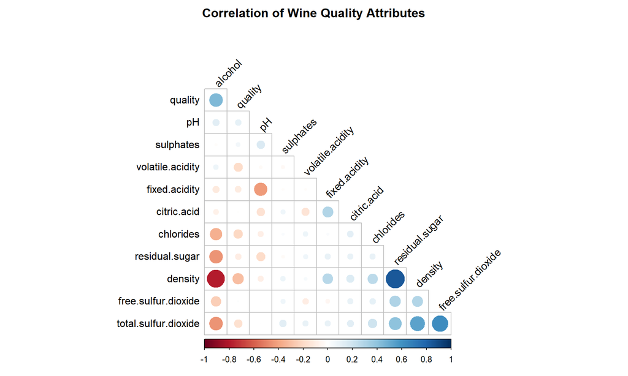

```r
#visualizing for better readablity
library(corrplot)
corrplot(correlation,
         type = "lower", order = "hclust",
         tl.col = "black", tl.srt = 45,
         title= "Correlation of Wine Quality Attributes",
         mar = c(0,0,2,0), # adjusting margins to show the title (bottom, left, top, right)
         diag = FALSE
         )
```

**Significant Correlations**

1. **Residual Sugar and Density:**
   - **Correlation**: `0.84`
   - **Interpretation**: Very `high positive correlation` indicating that as residual sugar increases, density tends to increase as well. This makes sense because sugar usually adds to the density of liquids.
2. **Alcohol and Density:**
   - **Correlation**: `-0.78`
   - **Interpretation**: `Strong negative correlation.` As alcohol increases, the density decreases. This also makes sense because alcohol is less dense than water.
3. **Free Sulfur Dioxide and Total Sulfur Dioxide:**
   - **Correlation**: `0.62`

**Other notable Correlations**

1. **Quality and Alcohol:**
   - **Correlation**: `0.44`
   - **Interpretation**: Mild positive correlation suggesting that higher alcohol content might be associated with higher wine quality.
2. Some features are not correlated at all with the target vairable and could be removed later in feature selections

### **Class Distribution:**

```r
# count of each rating of the quality column
quality_counts <- table(white_wine$quality)
quality_counts
```

```
##
##    3    4    5    6    7    8    9
##   20  163 1457 2198  880  175    5
```

```r
# percentage of each rating
quality_percentage <- quality_counts / nrow(white_wine) * 100
round(quality_percentage, 2)
```

```
##
##     3     4     5     6     7     8     9
##  0.41  3.33 29.75 44.88 17.97  3.57  0.10
```

**Conclusion**

### **SAMPLING?**

- `UPSAMPLING` could be used but this made it very extensive computationally because it increased the dataset by a very big number
- `DOWNSAMPLING` isn’t recommended here because this will cause loss innformation because there are only 5 data points in the quality range 9

### **Handling Zero-Variance Predictors**

```r
library(caret) # required library
nearZeroVar(white_wine, saveMetrics = TRUE)
```

```
##                      freqRatio percentUnique zeroVar   nzv
## fixed.acidity         1.062069     1.3883218   FALSE FALSE
## volatile.acidity      1.039526     2.5520621   FALSE FALSE
## citric.acid           1.088652     1.7762352   FALSE FALSE
## residual.sugar        1.016304     6.3291139   FALSE FALSE
## chlorides             1.005000     3.2666394   FALSE FALSE
## free.sulfur.dioxide   1.212121     2.6949775   FALSE FALSE
## total.sulfur.dioxide  1.131148     5.1245406   FALSE FALSE
## density               1.049180    18.1706819   FALSE FALSE
## pH                    1.048780     2.1028991   FALSE FALSE
## sulphates             1.106667     1.6129032   FALSE FALSE
## alcohol               1.004386     2.1028991   FALSE FALSE
## quality               1.508579     0.1429155   FALSE FALSE
```

**Conclusion**:

- There isn’t any `non zero variance` feature which mean no features to drop at this point.

# **Data Visualization**

### **Attributes Histogram**

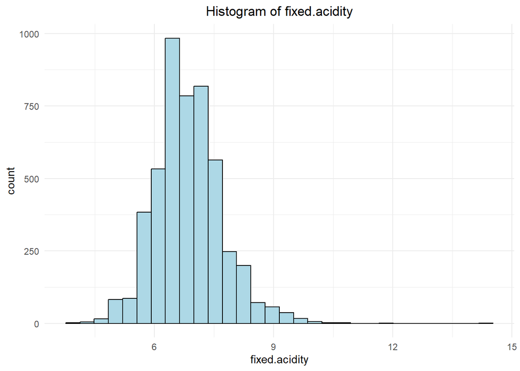

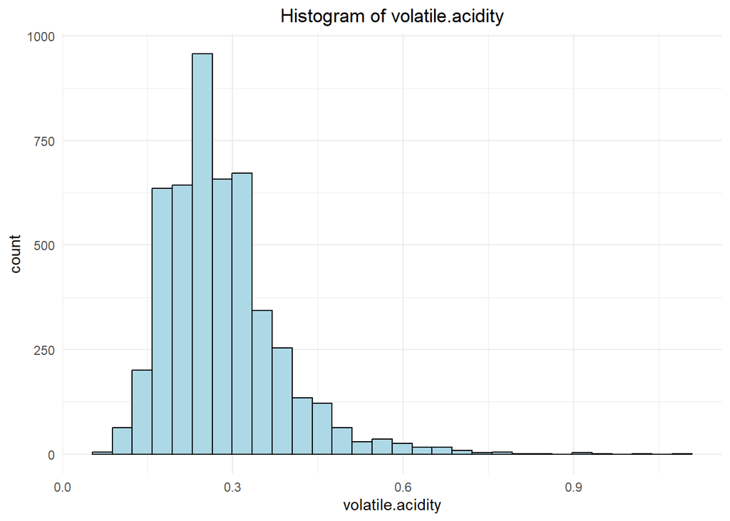

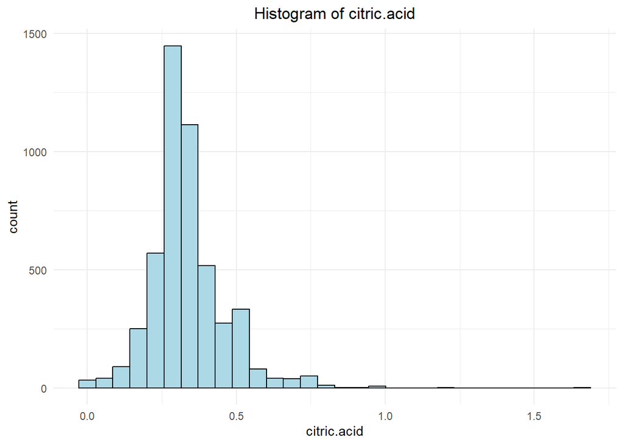

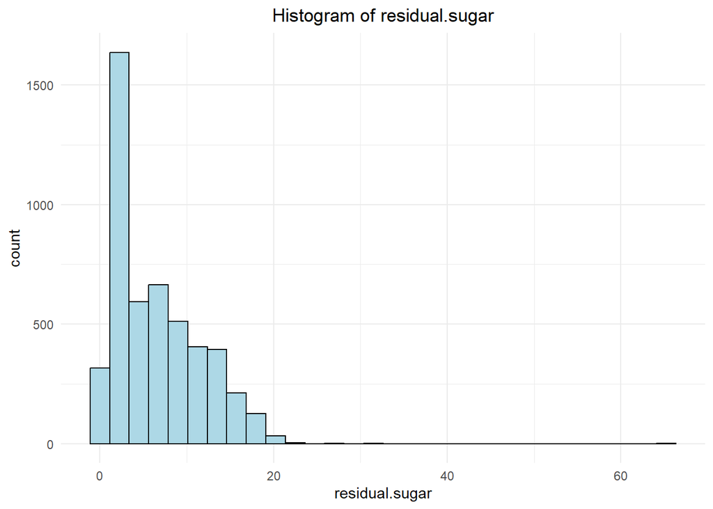

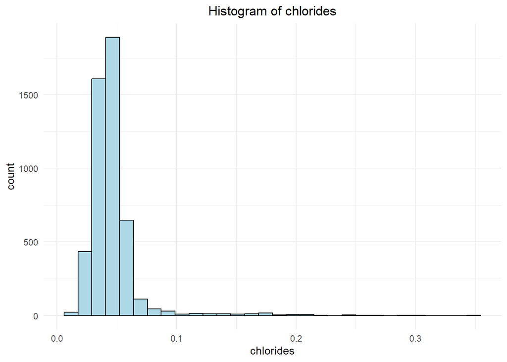

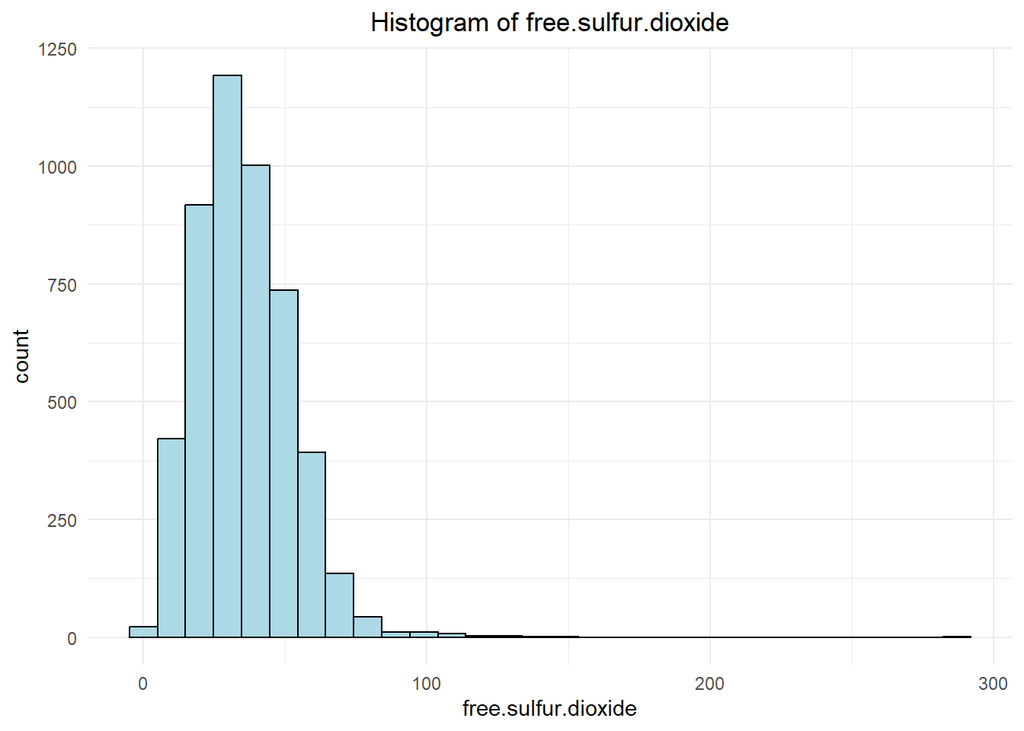

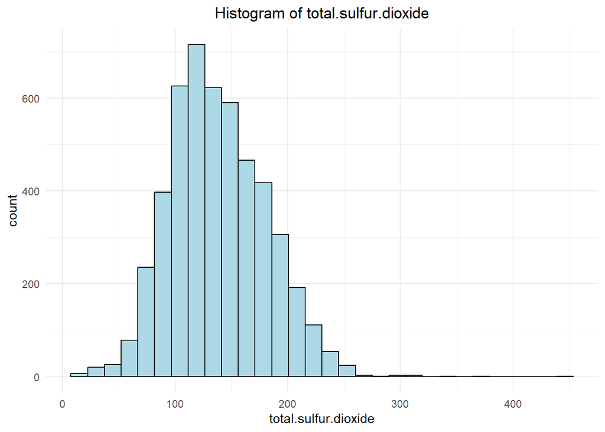

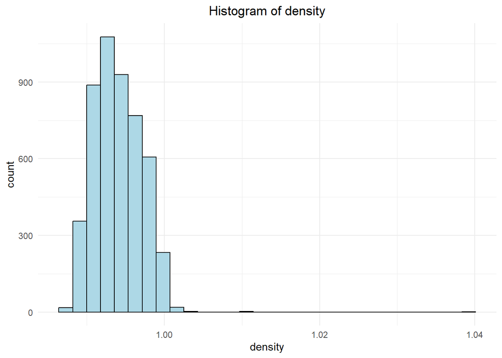

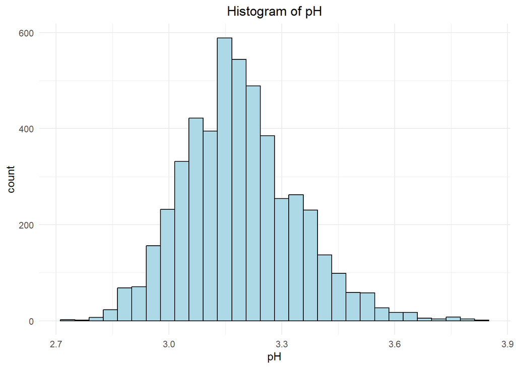

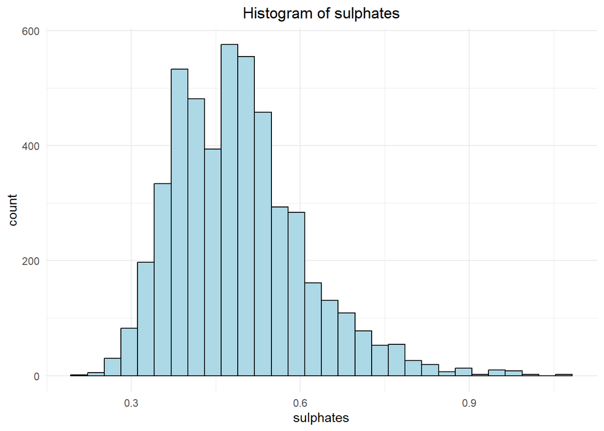

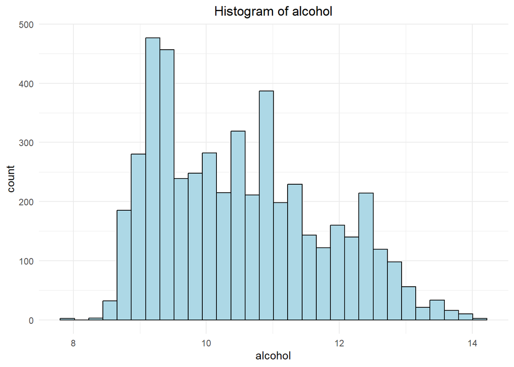

```r
library(ggplot2) # required library for plotting

for(i in names(white_wine)[-12]) { #
    p <- ggplot(white_wine, aes_string(x = i)) +
         geom_histogram(bins = 30, fill = "lightblue", color = "black") +
         ggtitle(paste("Histogram of", i)) +
         theme_minimal() +
         theme(plot.title = element_text(hjust = 0.5))
    print(p)
}
```

**Conclusion:**

- **Ranges vary** from one attribute to another, indicating diverse characteristics in the wine dataset.
- **Outliers are present** in several attributes.
- Some attributes show a **symmetrical shape**
- Most attributes are **right-skewed** indicating higher values are less common.

### **Density_Plots**

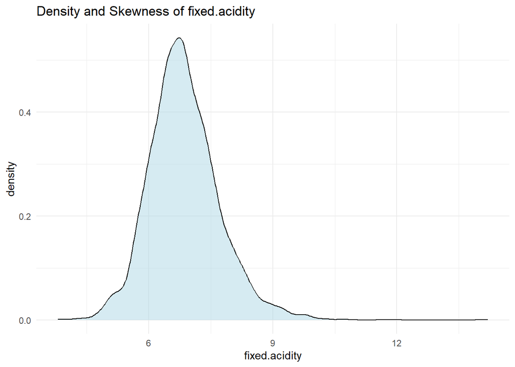

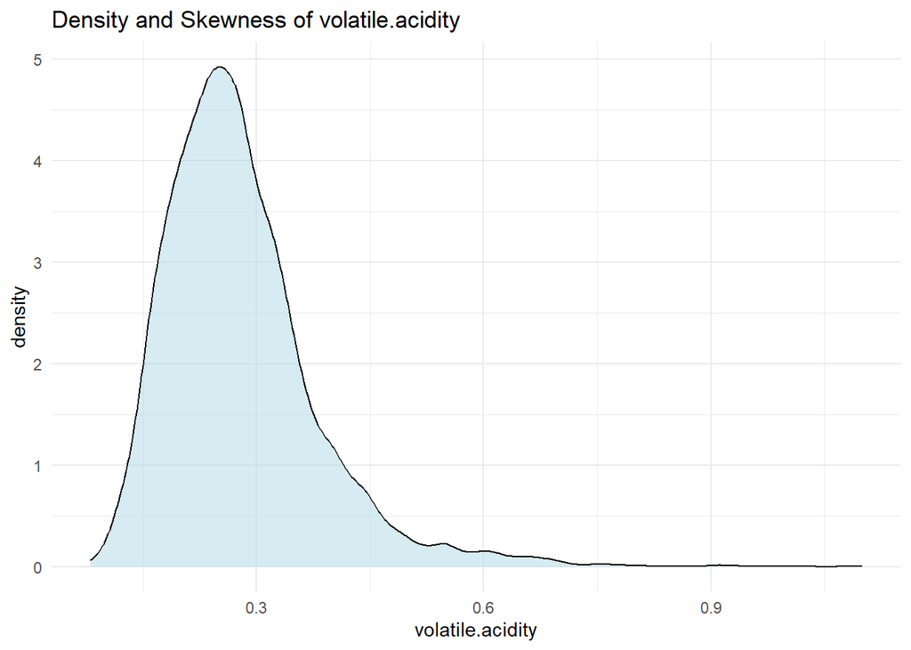

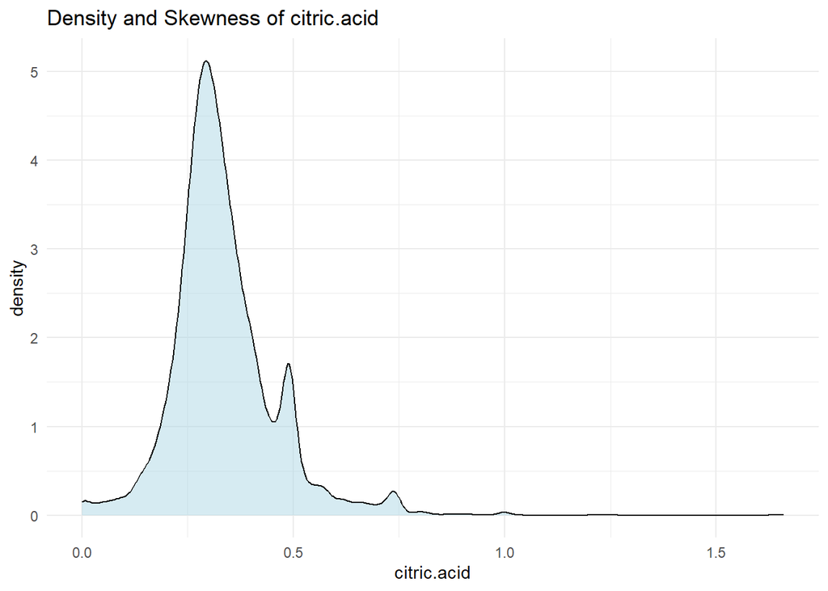

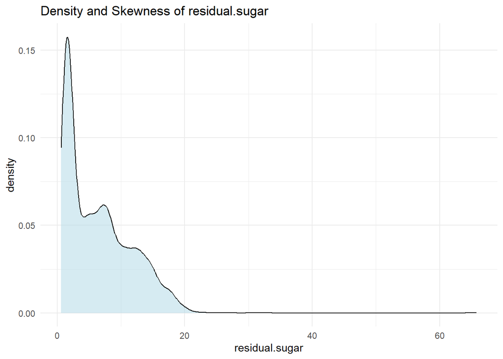

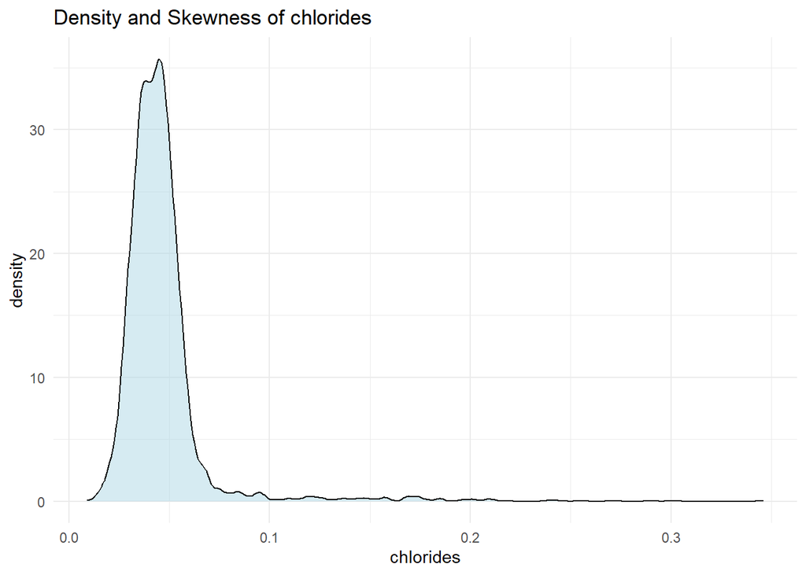

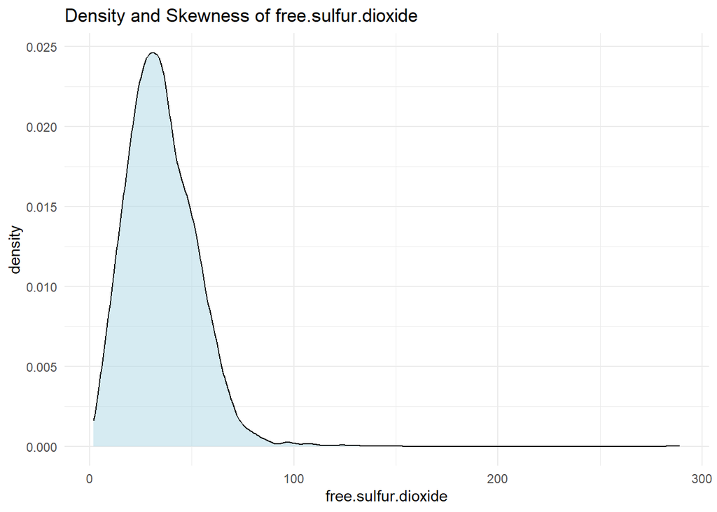

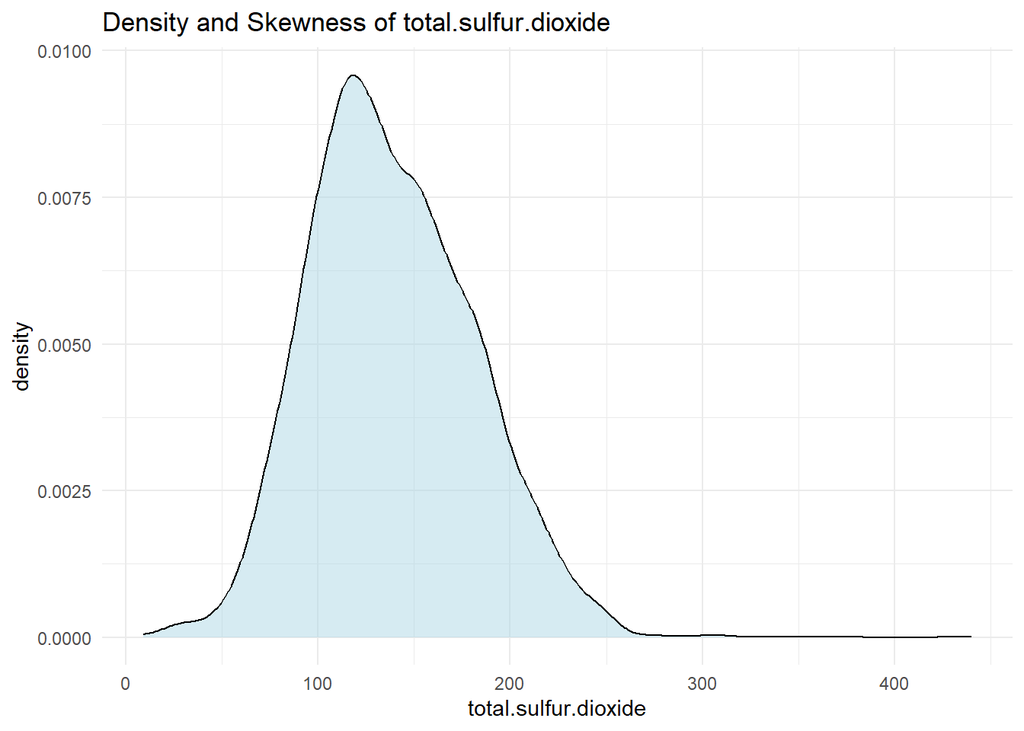

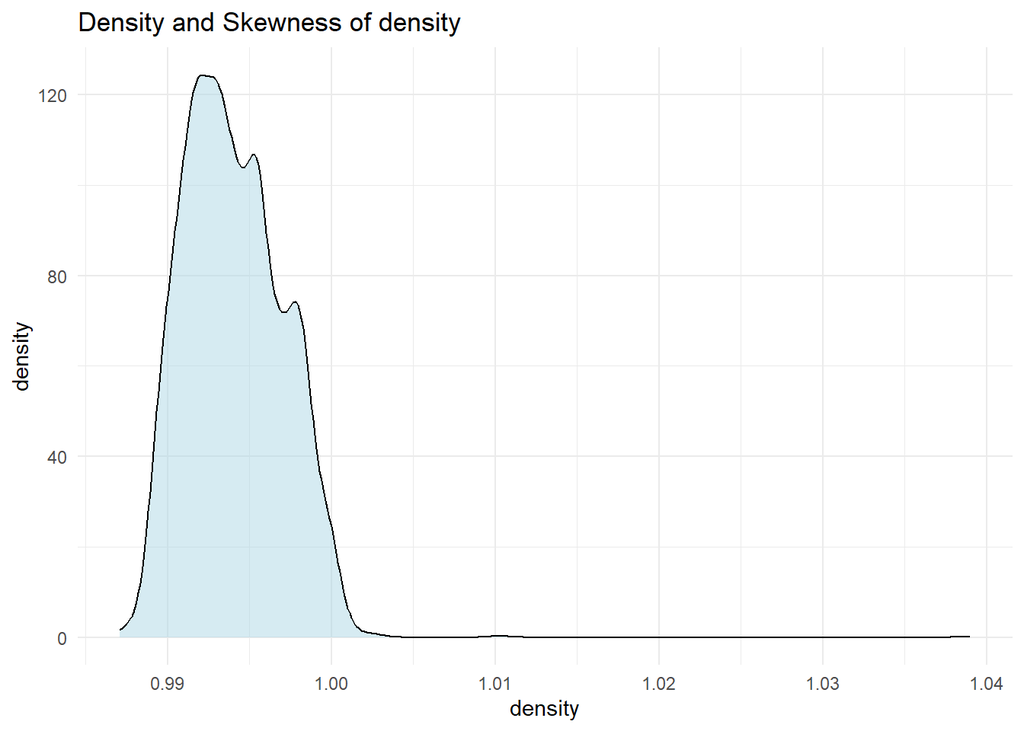

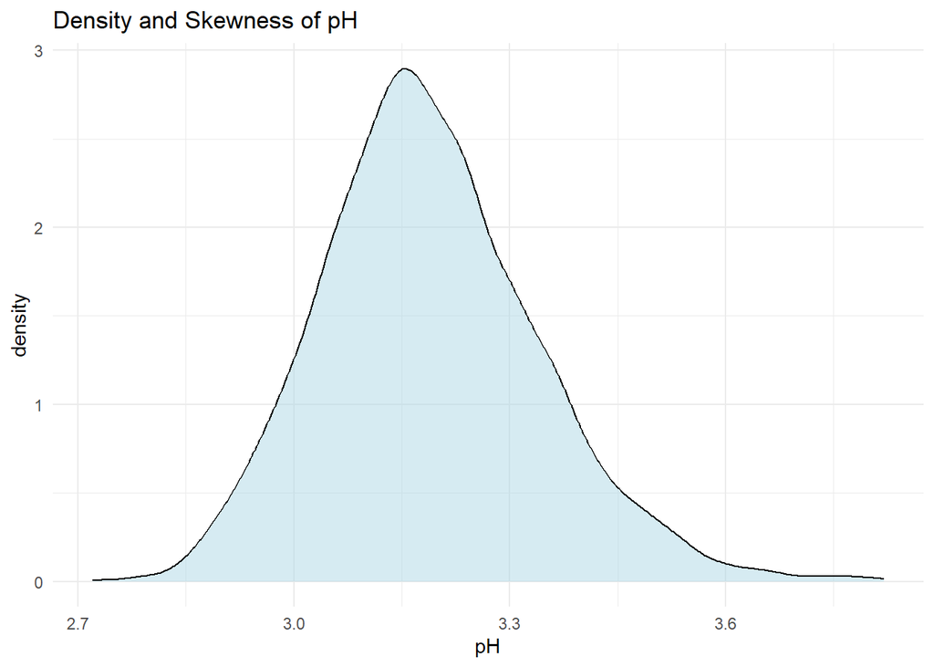

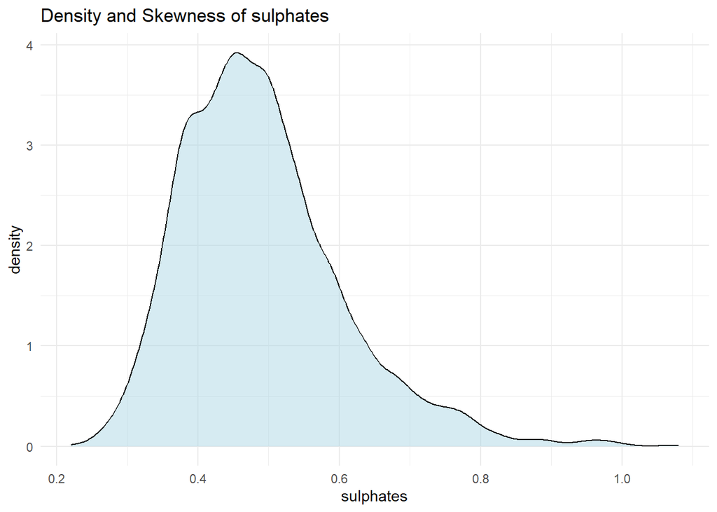

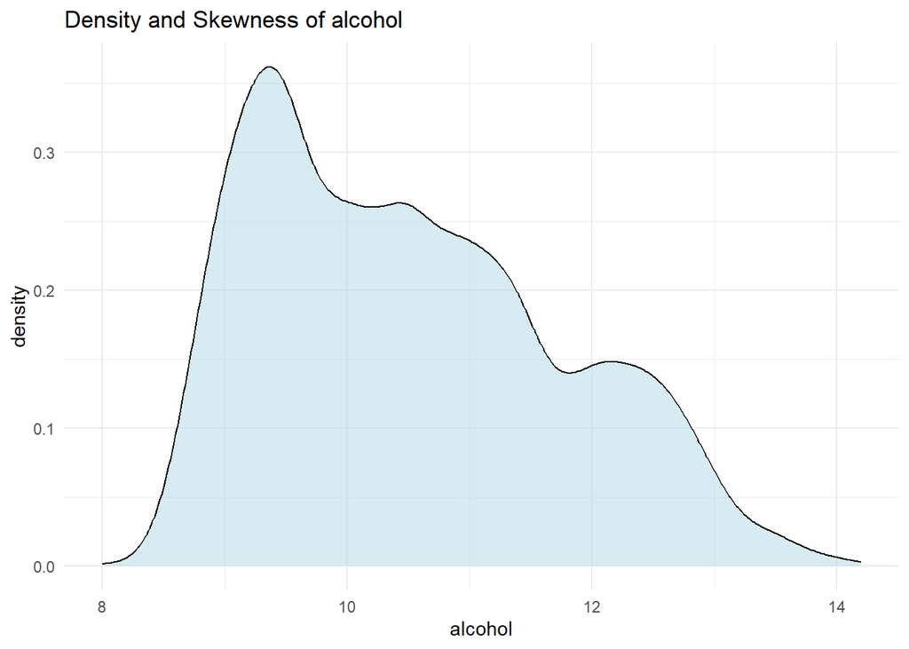

```r
for(i in names(white_wine)[-12]) {
    p <- ggplot(white_wine, aes_string(x = i)) +
         geom_density(fill = "lightblue", color = "black", alpha = 0.5) +  # Density plot
         ggtitle(paste("Density and Skewness of", i)) +
         theme_minimal()
    print(p)
}
```

**Conclusion:**

- `PH` is normally distributed
- The rest of the attributes are `positively skewed` indicating that most values are on the lower side of the range for this specific attribute with presence of outliers

### **Target Distribution**

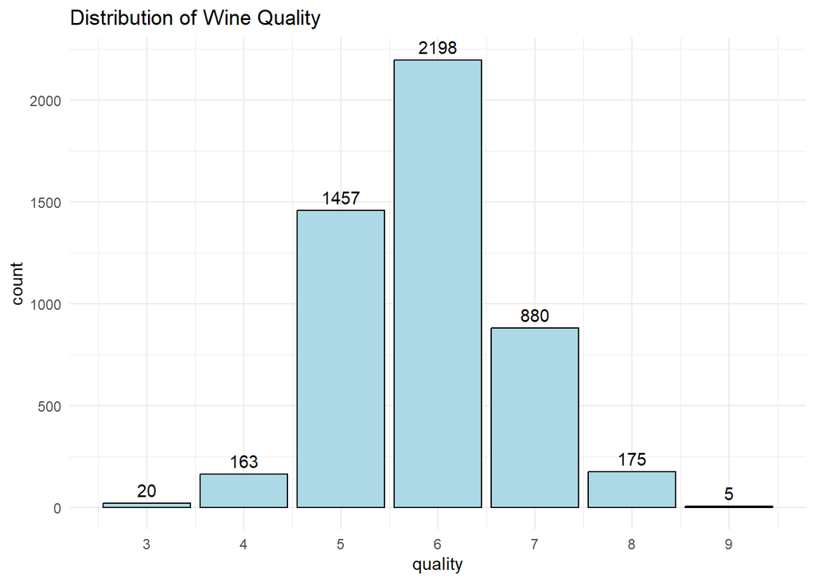

```r
ggplot(white_wine, aes(x = quality)) +
  geom_bar( fill = "lightblue", color = "black") +
  labs(title = "Distribution of Wine Quality") +
  geom_text(stat = "count", aes(label = after_stat(count)), vjust = -0.5) + #  showing value counts
  scale_x_continuous(breaks = seq(3, 9, by = 1)) +
  theme_minimal()
```

**Conclusion**:

- Data is highly imabalnced as mentioned before and there is a lot of normal wines (ranging from 5 - 7) more than very bad (3) or very good (9) wines

### **Box Plots of all features**

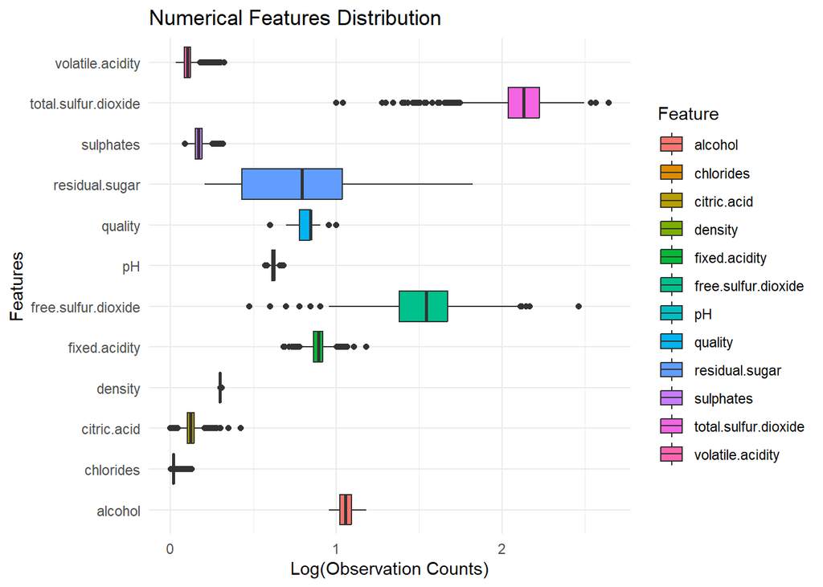

```r
library(tidyr)
long_data <- pivot_longer(white_wine, cols = everything(), names_to = "Feature", values_to = "Value")

ggplot(long_data, aes(x = Feature, y = log10(Value +1), fill = Feature)) + # used the log to scale the features for better visualization
  geom_boxplot() +
  coord_flip() +
  labs(y = "Log(Observation Counts)", x = "Features", title = "Numerical Features Distribution") +
  theme_minimal()
```

**Conclusion**

- Once again even after using the log we can see that all the features have different ranges and `scaling` should be used specially with Models like SVM that depends on calculating distances in a way.